# RAMP - Simulation-based Analytics

Demonstration

David L Smith, Sean L Wu

2023-01-31

`~/Model Building/Demonstration.Rmd`

HUB – Roadmap – Library – Model Building – `mob_library` – Active

## $\odot$

Suppose you want to build a model to give policy advice to a malaria program. You think carefully about the problem, develop a concept, and translate it into an equation or a system of equations. You’ve got something you could call a model.

It’s time for some analysis – or maybe this analysis was part of the original development. Either way, it’s a good idea to analyze your model. Maybe you’ll find out there’s an error in your logic. You don’t want to publish a model with a mistake in it.

If you’re being responsible, now’s the time to get some peer review. Is this a good model? Does it accurately represent the process? Is it new?

Now, it’s time to compute. There’s only so far you can go with pencil and paper, so it’s time to write some code. Then you need to verify the code – does this code accurately instantiate the equations I wrote down? If you run the code, does it finish the job in a reasonable amount of time?

If this is advice about malaria in a place, you will want to be able to fit the basic model to data.

Now, it’s time to evaluate some policy scenarios, so you modify your model, repeating everything up to here. You walk into the room to give your presentation, and the malaria program tells you that they’ve changed their strategy, but they need help with something closely related. Can you help?

Or you give your presentation, but someone in the room asks a question about some part of your model or analysis. They express skepticism. This person is important enough to decide whether your model gets used or not. Can you address their skepticism? If you took the criticism into account, would your advice still hold?

If we want to use simulation models for modeling we want to be nimble and give advice that is robust to uncertainty. We probably want to replicate our analysis thousands of times using different models. To serve these ends, we developed a framework that is modular, flexible, and extensible for modeling malaria. Then we built the software and some workflows to dramatically lower the costs of model building, model calibration, and of replicating an analysis .

- `Intro` – a very brief introduction
- `Setup` – how to set up `exDE` and run this demo
- `xde_setup()` – an overview of `xde_setup()`

## Intro

The software package [`exDE`](https://github.com/dd-harp/exDE) was designed to help people build, solve, and analyze systems of differential equations describing malaria and other mosquito-transmitted pathogens. The underlying mathematical framework was designed to be modular, flexible, and extensible to have the capability of building malaria models that are realistic enough to serve the needs of malaria programs [1]. In `exDE,` very complex models can be developed by passing simple *scripts* or instructions to `xde_setup()`, and new models can be developed by modifying existing models. A rigid mathematical framework constrains the interactions among model components, so the end user can build or modify models with some guarantees of mathematical consistency. The end user can imagine a model they need to support malaria policy, and then develop code that will solve it without having to learn all of the numerical recipes and coding that are required. The software dramatically lower the costs of doing complex simulation-based analytics, and to do it with code that has been tested and verified so that the computation is done with a high degree of competence.

The role of `exDE` is illustrated by comparison to the task computing $\sqrt{2}$. At one point, you might have learned a simple algorithm to compute it (*e.g.* a bisection algorithm), but it’s also possible to push a button on a calculator. Or you could ask `R` to compute it:

```r
sqrt(2)
```

```
## [1] 1.414214
```

It’s instructive, perhaps even fun, to learn something like the algorithm for computing $\sqrt{2}$, but you can just push the button.

The software we’re demonstrating here serves the same role as your calculator. The most important thing is to understand malaria well enough to ask the right questions. The software makes it easy to use models to answer those questions. *Someone* should know how the software works, just like someone should understand what a calculator is doing. Most policy teams should employ a few mathematically competent people who know what’s going on under the hood – perhaps to flag issues that might get missed otherwise – but it’s awfully useful to have a button.

How easy is it to build and solve the Ross-Macdonald model? A version of it, from a paper by Aron & May [2] is the default setting for the function`xde_setup()` so it would only take a line. We want to modify it a bit to show off.

First, we set up some options so that forced emergence has a sinusoidal seasonal pattern:

```r
Lo = list()
Lo$Lambda = 1000
Lo$Lt = function(t, pars){1000*(1.0+sin(2*pi*t/365))^2}
```

Now we set up the model:

```r
xde_setup("ross_macdonald", Lopts = Lo) -> ross_macdonald
```

It takes one more line to solve it, which we attach to the model object:

```r
ross_macdonald<- xde_solve(ross_macdonald, Tmax=2000)
```

A function returns the variables by name, so we can plot the quantities with ease:

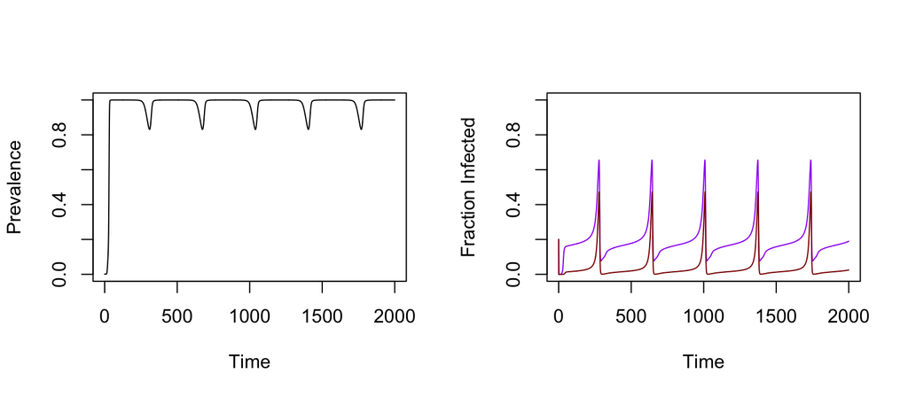

```r
par(mfrow = c(1,2))
xde_plot_PR(ross_macdonald, 1)
xde_plot_YZ_fracs(ross_macdonald, 1)
```

The `xde_setup()` function from `exDE` is an easy way of building very complex models. (We discuss the topic in the `setup` tab that follows, but we introduced modular notation already. You can read about it as html) and as a [pdf supplement to *Spatial Dynamics of Malaria Transmission*](https://doi.org/10.1371/journal.pcbi.1010684.s002) [1].

The software we wrote was designed to support nimble model building. We wanted to make it easy to deal with a very large set of mathematical issues – mainly numerical and computational – using the mathematics, while drawing as little attention to the math as possible. With this tool in hand, we hope to make it easier to use models in policy discussions that focus on the data, concepts, and decisions.

We don’t want to give a wrong impression: we recognize that malaria is complex, so addressing policy issues with a high degree of competence requires careful thought that is based on a thorough understanding of malaria programs, malaria epidemiology, mosquito ecology, transmission, and the models. Even with knowledge and intuition, walking through the steps required to do an analysis requires hard work and effort to construct a well-designed, creative and critical analysis. The software can help, but someone will have to get their hands dirty. The point of this software is to reduce the costs of doing all the things required to do it well.

The software also addresses another need. The resulting analyses are easy to replicate and easy to modify.

What are the problems we trying to solve? The big picture here is to eliminate malaria, and meanwhile to save as many lives as possible. These activities required to achieve these goals are ultimately managed by national malaria programs. Some part of the challenges facing malaria programs involve managing the human element and logistics. The decisions and policies are usually based on data collected through routine surveillance collected through health management information systems (HMIS).

Turning data into information, and then turning information into policy advice goes well beyond doing a cursory examination of the routine surveillance data. The challenges facing malaria programs are how to use their HMIS data to understand what is happening in their communities, including evaluation of ongoing malaria control efforts. This involves some kind of synthesis. National malaria programs should be actively working to identify and gather data they need to make good policy decisions. All this requires a linked set of activities to try and understand how malaria in communities. HMIS data must be aligned with research data to try and understand the causes of the biases in the data and the processes – mosquito ecology and transmission, care seeking and treatment, and vector control – that make up the dynamics and control of malaria.

The software was designed to fill a specific role within a broader ecosystem of software and analysis. We expect that the analysis will be done by a team and that some members of the team will have the required expertise, when it is needed. We also expect the discussions to be focused on the core challenges, and not on the technical details required for implementation.

That being said, there’s a lot to learn, because the software covers a lot of topics (see the Figure, below)

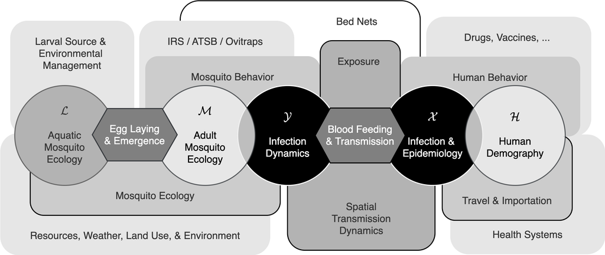

**An overview of exDE capabilities**

## setup

### `R`

We assume you have a working knowledge of R and RStudio. It’s probably a good idea to use the latest versions, and you will probably need to download or update several R packages to get up and running. There are many required, but the numerical algorithms rely on these two:

- `deSolve` is the core software to solve differential equations.
- `expm` does matrix exponentiation

### `RAMP`

The current state of the RAMP Model Library can be viewed at:

> https://dd-harp.github.io/RAMP-Staging/RAMP-Model-Library.html.

This file is viewable there as:

> [https://dd-harp.github.io/RAMP-Staging/Model Building/Demonstration.html](https://dd-harp.github.io/RAMP-Staging/Model%20Building/Demonstration.html).

If you want to access to the underlying code, you will need to clone the `RAMP-Model-Library`. If you don’t have permission, please ask dave.

After cloning the library, you can browse the content in the `RAMP-Model-Library` by opening a local file:

> RAMP-Model-Library.html

To follow along this file as R markdown:

> `RAMP-Model-Library/Model Building/Demonstration.Rmd`

### `exDE`

Download the latest version of `exDE.` The version at CRAN might be out of date, so please load the package from the `github`:

```r
library(devtools)
devtools::install_github("dd-harp/exDE")
```

…and then install it:

```r
library(exDE)
```

The package is updated frequently, so if you start encountering errors, please try to repeat this sequence, remembering to restart R aver installing from github so that you’re using the latest version of `exDE.`

### `mobwork`

We’ll be using `mobwork`, which has the full catalogue of models for the library.

```r
library(devtools)
devtools::install_github("dd-harp/mobwork")
```

…and then install it:

```r
library(mobwork)
```

The package is updated frequently, so if you start encountering errors, please try to repeat this sequence, remembering to restart R aver installing from github so that you’re using the latest version of `mobwork.`

## xde_setup

### $\oplus$

Most people are introduced to malaria transmission through the Ross-Macdonald model [(reviewed at PLoS Pathogens)](https://journals.plos.org/plospathogens/article?id=10.1371/journal.ppat.1002588) [3], usually in a college course, but after that course, there’s still a lot to learn.

`exDE` has a modular design and built-in features to handle most aspects of mosquito ecology or malaria transmission dynamics and control. Model building involves making a set of choices about the **core dynamics,** the **structural elements,** and a set of **options** that can add realism to the models. The set of choices can be overwhelming, so we start with simple models and build in complexity one piece at a time. We gave the name “scalable complexity” to the design principle that guided development of `exDE` that makes all this possible.

We put a lot of time into the design of `exDE` to implement the plug-and-play design. In the design phase, we made a lot of mistakes – decisions that made it difficult to combine or extend the model in other ways. In designing the computational interface, we had to think carefully about each feature and decide how it would have to interact with other model features. If you use the tools that come with `exDE` – including `mob_setup` and `mob_work` – a lot of this is invisible to the end user. If you decide to build models by hand, you might find your work more difficult.

- `Dynamics` – the dynamical systems describing mosquito ecology and infection dynamics, and the dynamics of parasite infections in humans.
- `Structure` – the configuration of aquatic habitats; patch dynamics; and human population strata to deal with heterogeneity

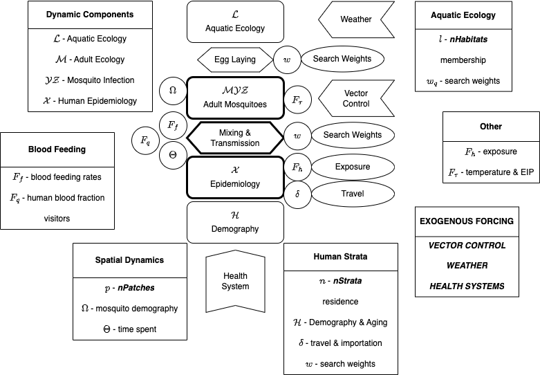

**Model Configuration Options**

### Dynamics

The algorithms at the core of these models are differential equations describing a system with three components. Each component is defined by a state space and a function that describes changes to the state variables – the derivatives with respect to time.

- We define a state space describing a human population ($\cal H$) and the dynamics of infection and immunity ($\cal X$). The model library includes many well-defined models published by others, and some of our own.
- We define a state space describing an adult mosquito population ($\cal M$) and the dynamics of infection and infectiousness ($\cal YZ$). The model library includes many standard formulations of adult mosquito dynamics and behavior, including utilities for dealing with mosquito movement and *behavioral state models.*
- We define a state space describing an aquatic mosquito population ($\cal L$) and the dynamics of eggs hatching, and immature mosquito survival, maturation, pupation, and emergence. The model library includes several dynamical formulations.

Since the point of `exDE` is to reduce the costs of building models, so we will be working to expand the set of model families that fill these roles. We hope people will ask if the model they need has already been developed, and if so, has it already been added to the library.

An important feature of this framework is that we have developed modules so that each one of these components can be reduced to a **trace function.**. This is the trivial dynamical model, with `null` dynamics, but a configurable function that can pass its outputs to other modules.

### Structure

#### $\oplus$

We must determine how to stratify the population we’re interested in studying – this is what we mean by *structure.*

- $p$ or `nPatches` is a critical structural element. If `nPatches > 1` then we have a **spatial** model
- $n$ or `nStrata` is a structural element describing the number of humans in a population made up of strata strata. To set up a model, we do this by passing a vector `HPop` describing the number of people in each stratum ($H$), and `nStrata <- length(HPop)`.
- $l$ or `nHabitats` is a structural element describing the number of aquatic habitats. To set up a model, we pass a vector that has the index of the patch where each habitat can be found, called the `membership` vector, and `nHabitats <- length(membership)`.
- $s$ or `nSpecies` describes the number of mosquito species (or types) in a model. (**NOTE:** This hasn’t been implemented yet.)

#### Configuration

Depending on which model family we chose for each component, we will need to set the values of the parameters and initial conditions.

- For the state model describing human infections, $\cal X$, there are a set of parameters that must be set describing infection, immunity, disease, infectiousness, and detection:
  - If `nPatches>1` then it is necessary to configure a matrix, called the **Time Spent** matrix ($\Theta$), describing how humans spend their time. compute the **Time at Risk** matrix;
  - If `nStrata>1` then it is necessary to assign **Search Weights** to each stratum for the blood feeding algorithm.
- For the state model describing adult mosquitoes, $\cal MYZ$, there are a set of parameters that must be set describing survival, blood feeding, and infection:
  - To simulate adult mosquito population ecology and parasite infection dynamics in mosquitoes, we adopt a published **dynamical model** of malaria.
  - For the adult mosquito populations, it is necessary to configure a **mosquito demographic matrix** $\Omega$, including **mosquito movement**;
  - the **residence** vector identifies the location of home for each human population stratum
  - heterogeneous biting is modeled through a frailty term – each stratum is assigned a **search weights** that affect mosquito **blood feeding** behavior
- A built-in model of **blood feeding** can be used to compute **blood feeding rates** ($f$) and the **human blood fraction** ($q$), and transmission terms are computed through a structured interface that computes a mixing matrix, $\beta$;
- $l$ or `nHabitats` is a structural element
  - each habitat has a location in a patch;
  - the **membership** vector is the index of the patch where each habitat is found;
  - egg laying is determined by location and a set of habitat **search weights**

### Options

Some important options for humans are:

- Human demography is computed as part of $\cal X$, but it is a set of options $\cal H$ that can be configured to handle:
  - **Cohort dynamics** and aging;
  - **Births** and **deaths**
- **Malaria Importation** can be configured with importation through *travel malaria* ($\delta$) or *visitors*
- Exposure models convert the local EIR into the FoI:
  - $F_h$ is a model for **environmental heterogeneity** in local exposure
  - pre-erythrocytic immunity, $F_b$, can be configured
  - the travel FoI is to the local FoI.
- **Mass Medical Interventions** can be added to any model, including MDA.
- **Vector Control** can be added to any model
- **Exogenous Forcing** by weather and a range of other can be configured. The exogenous variables are computed separately:
  - There is a built-in function to compute the time-varying EIP, and the software was designed to compute survival and dispersal in delay differential equations with time-varying EIPs.
  - Models for mosquito ecology and behaviors can be modified by temperature, rainfall, and relative humidity.
- *Health System*

### xde_setup

`xde_setup` is an easy way to build a prototype. It is now defined in `exDE`

To set up a model, the following arguments are passed to `xde_setup.` All of these arguments are assigned default values that can be overwritten by passing a different value (*e.g.* `MYZname = "GeRM"`):

- `modelName` - assign a name to the model
- **Dynamical Components**
  - `MYZname` [character] - the name (in quotes) of a $\cal MYZ$ model (default = “RM”)
  - `Xname` [character] - the name (in quotes) of a $\cal X$ model (default = “SIS”)
  - `Lname` [character] - the name (in quotes) of a $\cal L$ model (default = “trace”)
- **Model Structure**
  - `nPatches` [numeric] (integer) - the number of patches
  - `HPop` [vector] (integer) :: $\rightarrow$ `nStrata = length(HPop)` - the number of humans in each stratum
  - `membership` [vector] (integer) ::$\rightarrow$ `nHabitats = length(membership)` the $i^{th}$ element of `membership` is the index of the patch where the $i^{th}$ habitat is found
- **Adult Mosquito Options**
  - `MYZopts` [list] :: a list of arguments to set options in either `MYZpar` or `MYZinits`
  - `calK` [matrix] or [character] :: if `calK` is a matrix, then it becomes `MYZpar$calK.` If `calK` is a name, then it dispatches another instance of `make_calK` (see setup_calK)
  - `calKopts` [list] :: a set of configuration options for `make_calK`
- **Human Options**
  - `Xopts` [list] :: a set of configuration options for `Xpar` or `Xinits`
  - `Hopts` [list] :: a set of configuration options for `Hpar`
  - `residence` [vector] (integer) & `length(residence) == nPatches` :: the $i^{th}$ element of `residence` is the index of the patch where the $i^{th}$ stratum resides.
  - `searchB` [vector] (numeric) & `length(searchB) == nStrata` :: the blood feeding *search weight* for each stratum.
  - `TimeSpent` [matrix] or [character] :: if `TimeSpent` is a matrix, then it becomes `Hpar$TimeSpent.` If `TimeSpent` is a name, then it dispatches another instance of `make_TimeSpent` (see setup_TimeSpent)
  - `TaRopts` [list] :: a set of configuration options for `make_TaR`
- **Aquatic Mosquito Options**
  - `Lopts` [list] :: a set of configuration options for `Lpar` or `Linits`
  - `searchQ` [vector] (numeric) & `length(searchQ) == nHabitats` :: the egg laying *search weight* for each aquatic habitat

## e.g.

### -

### Aron & May, 1982

#### Setup

```r
Lo = list()
Lo$Lt = function(t, pars){1000*(1.01+sin(2*pi*t/365))^2}
```

```r
xde_setup("aron_may", MYZname = "RM", Lopts=Lo) -> aron_may
```

```r
xde_solve(aron_may, Tmax=3650, dt=10) -> aron_may
```

#### plotting

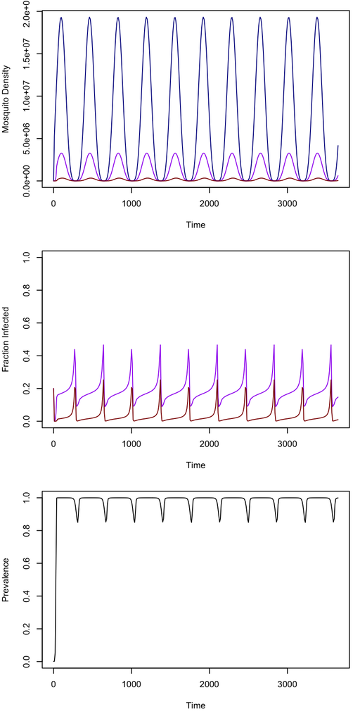

```r
par(mfrow= c(3,1), mar = c(5,4,1,1))
xde_plot_M(aron_may, 1)
xde_plot_YZ(aron_may, 1, add_axes=F)
xde_plot_YZ_fracs(aron_may, 1)
xde_plot_PR(aron_may, 1)
```

### 5-3-4

#### model

```r
Lo = list()
Lo$theta = 1/c(10, 20, 40, 100, 10)*15
```

```r
calK = t(matrix(
    c(c(0, .6, .3),
    c(.4, 0, .7),
    c(.6, .4, 0)), 3, 3)/3
)
```

```r
TiSp = t(matrix(
  c( c(0.01,0.01,0.001,0.001),
     c(.95,.92,.04,.02),
     c(.04,.02,.959,.929)), 4, 3)
)
```

```r
xde_setup("mod534", nPatches=3, calK=calK, MYZname="RM",
           Lname="basic", Lopts=Lo,
           membership=c(1,1,1,2,2), searchQ=c(7,2,1,8,2),
           HPop = c(10,90,100,900), residence=c(2,2,3,3),
           searchB=c(1,3,1,3), TimeSpent=TiSp) -> mod534
mod534a <- mod534
```

#### plots

```r
xde_solve(mod534, Tmax=15*365, dt=10) -> mod534
#Lambda = as.vector(tail(mod534$outputs$outputs$orbits$MYZ$M,1)*mod534$MYZpar$g0)*5
```

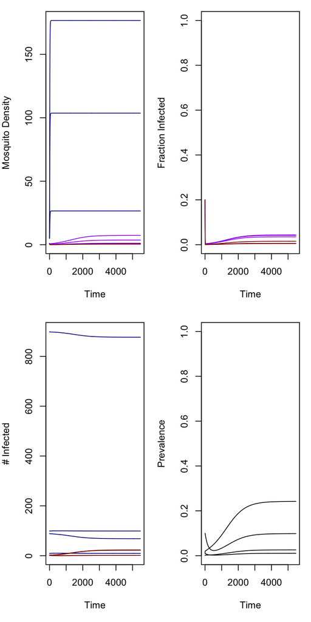

```r
par(mfrow= c(2,2), mar = c(5,4,1,1))
xde_plot_M(mod534, 1)
xde_plot_YZ(mod534, 1, add_axes=F)
xde_plot_YZ_fracs(mod534, 1)
xde_plot_X(mod534, 1)
xde_plot_PR(mod534, 1)
```

### 5-3-3

#### model

```r
Lo = list()
Lo$theta = 1/c(10, 20, 40, 100, 10)*15
```

```r
calK = t(matrix(
    c(c(0, .6, .3),
    c(.4, 0, .7),
    c(.6, .4, 0)), 3, 3)/3
)
```

```r
TiSp = t(matrix(
  c( c(0.92,0.01,0.001),
     c(.02,.92,.04),
     c(.05,.02,.959)), 3, 3)
)
```

```r
xde_setup("mod533", nPatches=3, calK=calK, MYZname="RM",
           Lname="basic", Lopts=Lo,
           membership=c(1,1,1,2,2), searchQ=c(7,2,1,8,2),
           HPop = c(10,100,1000), residence=c(1,2,3),
           searchB=c(1,1,1), TimeSpent=TiSp) -> mod533
mod533a <- mod533
```

```r
xde_solve(mod533, Tmax=25*365, dt=10) -> mod533
Lambda = as.vector(tail(mod533$outputs$orbits$MYZ$M,1)*mod533$MYZpar$g0)*5
```

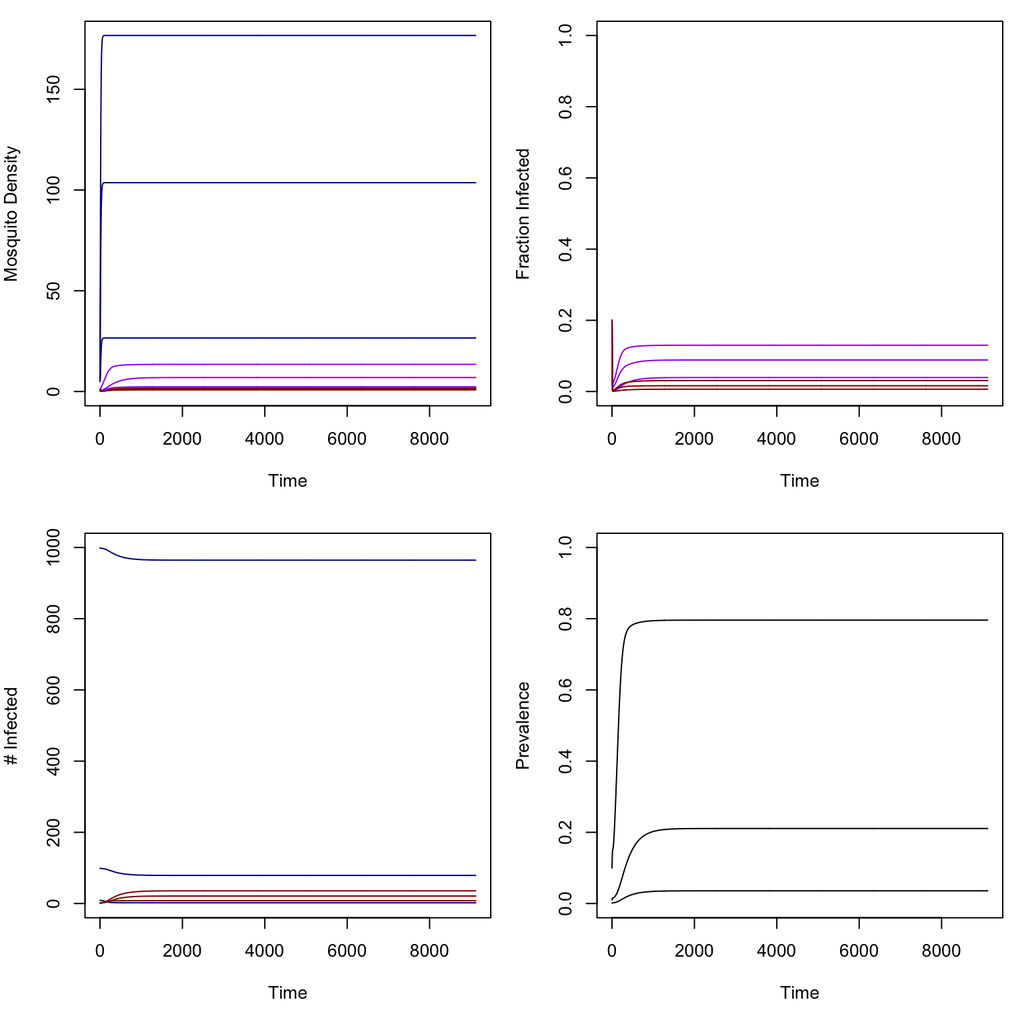

```r
par(mfrow= c(2,2), mar = c(5,4,1,1))
xde_plot_M(mod533, 1)
xde_plot_YZ(mod533, 1, add_axes=FALSE)
xde_plot_YZ_fracs(mod533, 1)
xde_plot_X(mod533, 1)
xde_plot_PR(mod533)
```

```r
mod533a <- last_to_inits(mod533)
mod533a$nHabitats <- mod533$nPatches
mod533a$calN <- diag(1, mod533$nPatches)
mod533a = make_Lpar_trace(mod533a, Lambda = Lambda)
mod533a <- make_indices(mod533a)
```

```r
pr = tail(mod533$outputs$orbits$pr, 1)
L = c()
```

```r
L = c(mod533c$Lpar$Lambda, tail(mod533c$outputs$orbits$pr, 1))
```

```r
wts = c(0, 0, 100)
mod533a$Lpar$Lambda = Lambda*wts
#mod533a$Lpar$Lambda[3] = 0
mod533c <- fitLambda_lss(pr, mod533a)
mod533c <- xde_solve(mod533c, 3650, 10)
```

```r
L = rbind(L, c(mod533c$Lpar$Lambda, tail(mod533c$outputs$orbits$pr, 1)))
L
```

[output not shown]

## scaling

### -

Before we apply the framework, it’s worth learning a bit about the built-in functionality and capabilities. In malaria, we measure exposure to malaria entomologically using a metric called the entomological inoculation rate (EIR), and we measure infection using a metric called the parasite rate (PR). The PR is frequently measured, but the EIR is not, so we want to establish a basis for estimating the EIR from the PR, even though the causal relationship goes in the other direction. An important factor is that the PR tends to vary by age.

Studies have identified several factors that affect this relationship (See Figure 1):

- Every model proposes a slightly different baseline relationship between the EIR and the PR.
- The PR is affected by taking drugs that cure infections and provide a few weeks of chemoprotection.
- Exposure to malaria is heterogeneous:
  - In most places, exposure to malaria is seasonal.
  - Heterogeneous biting is a kind of frailty – different strata can have different exposure rates for many reasons. The model handles this kind of heterogeneity through **search weights,** which are integrated into simulations through the algorithms that compute **blood feeding** and **transmission.** An important factor here is **age.**
  - Environmental heterogeneity describes the distribution of the mean rate of exposure in a population: we formulate a hazard rate that is consistent with the observation that the number of infectious bites, per person, will tend to follow a *negative binomial* distribution. This affects the functional relationship between the EIR and the FoI.
- An important part of exposure includes travel and exposure to malaria away from home.
- When we predict the PR, we want to be aware of context and methods, so we consider the observational process. What methods were used to catch mosquitoes? What was the study design, and how well could the methods detect infection?

These factors are summarized in Figure 1.

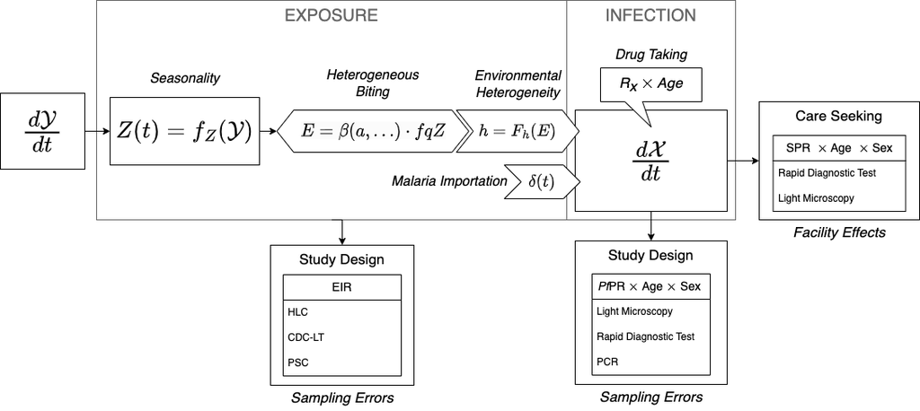

Figure 1

### eir2pr

In `mob_work,` we developed the `eir2pr` family of functions. Each model implies a scaling relationship between the EIR and the PR. It’s too hard to deal with everything all at once, but we can add complexity one step at a time.

This is the simple SIS model with two different values for the rate of clearance:

```r
F_eir0 = function(a, bday=0, scale=1){scale*(0*(a+bday)+1)}
xde_setup_cohort(F_eir0) -> mod0
xde_solve(mod0) -> mod0
mod0$eir = 1000
mod0$Xpar[[1]]$r = 1/200
mod0 <- xde_scaling_eir(mod0)
mod1=mod0
mod1$Xpar[[1]]$r = 1/100
mod1 <- (mod1)
mod1 <- xde_scaling_eir(mod1)
```

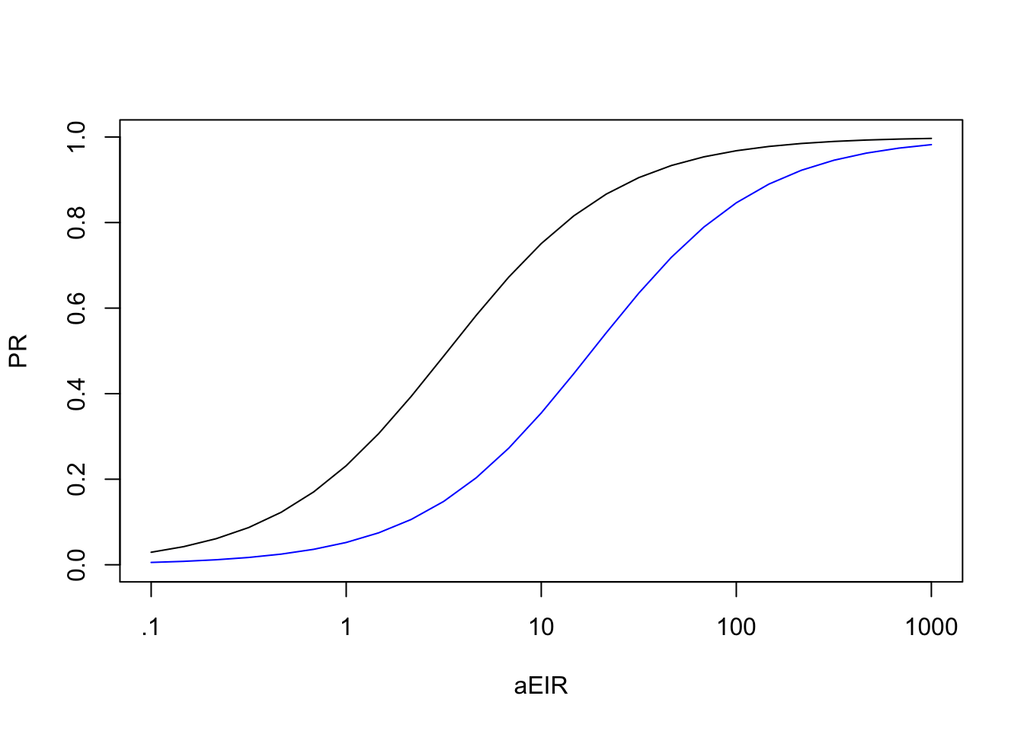

```r
plot_eirpr(mod0)
lines_eirpr(mod1, clrs="blue")
```

## BIMEP

### -

We will demonstrate the capabilities of the software using the example of malaria on Bioko Island, Equatorial Guinea. Intensive malaria control was implemented on Bioko Island starting in 2004. The data we use come from the Bioko Island Malaria Elimination Program (BIMEP). The goal of these simulation-based analytics are to support analysis of ongoing vector control, which includes:

- distribution of long-lasting, insecticide treated bed nets (LLINs)
- indoor residual spraying (IRS)
- starting this year, larval source management (LSM)

We would like to understand malaria transmission now as a **changing baseline** that has been **modified by vector control.** Our analysis will start simple and add realism one step at a time. This demonstrates the capabilities of `exDE` and it also establishes a simple method for replicating this sort of analysis for other systems. Among the problems we would like to address:

- **Malaria Importation:** Several papers have described the problem of malaria importation [4]…
- Age

A core challenge is that we would like to develop a quantitative understanding of malaria using the data we have.

### Basic

#### -

We want to start with a very simple analysis using the Ross-Macdonald model.

#### sim

```r
xde_setup("aronmay")->aronmay
```

```r
aronmay=xde_solve(aronmay)
```

#### fit

#### sum

### Exposure

### $R_x$

### Travel

### Space

### Age

### Time

### Control

## $\boxplus$

## $\dagger$

1.

Wu SL, Henry JM, Citron DT, Ssebuliba DM, Nsumba JN, C HMS, et al. Spatial dynamics of malaria transmission. PLOS Computational Biology. 2023;19: e1010684. doi:10.1371/journal.pcbi.1010684

2.

Aron JL, May RM. The population dynamics of malaria. In: Anderson RM, editor. The Population Dynamics of Infectious Diseases: Theory and Applications. Boston, MA: Springer US; 1982. pp. 139–179. doi:10.1007/978-1-4899-2901-3_5

3.

Smith DL, Battle KE, Hay SI, Barker CM, Scott TW, McKenzie FE. Ross, Macdonald, and a theory for the dynamics and control of mosquito-transmitted pathogens. PLoS Pathog. 2012;8: e1002588. doi:10.1371/journal.ppat.1002588

4.

Guerra CA, Kang SY, Citron DT, Hergott DEB, Perry M, Smith J, et al. Human mobility patterns and malaria importation on Bioko Island. Nat Commun. 2019;10: 2332. doi:10.1038/s41467-019-10339-1